# How We Interact with Ads on Social Media

## What is this data about? (fig.1)

This data was collected through self-observation across several social media platforms over a few weeks in March and May 2025. Each row in the dataset represents a moment where I recorded my platform, activity, the number of ads seen, their relevance, and whether people interacted with them.

The goal of this story is to understand **how ads are distributed across platforms**, how **user engagement activities** affect ad frequency, and how **relevant or interactive** these ads appear to be.

## How Often Do We Interact with Ads?

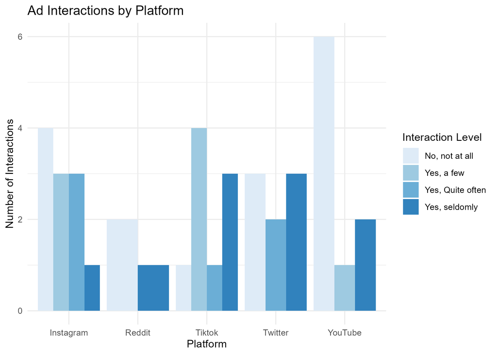

*What this means?*

YouTube has an incredible bar of no interactions with their given ads. Reddit was responded in the Other box. Overall **good spread** among the bar graph of the **Interaction Levels in their given platforms**.

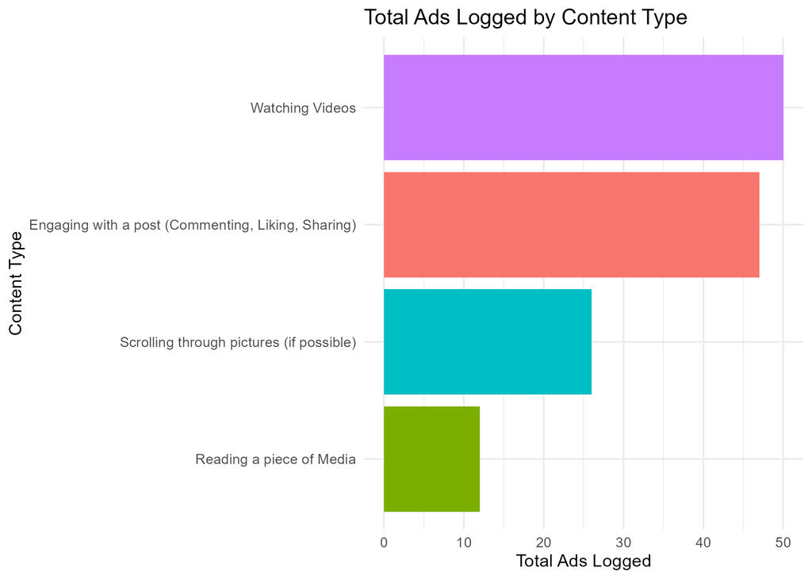

*Watching Videos*

As it seems, **engaging with the data or Watching video media** has a higher number of total ads logged, this could broadly be explained to fulfill cases in which people engaging with content will spend time on that platform generating ads, Watching Videos generate ad breaks in most platforms, meaning the control of incoming ads is entirely upto the platform.

## Do Entertainment Ads Feel More Relevant? (fig.3)

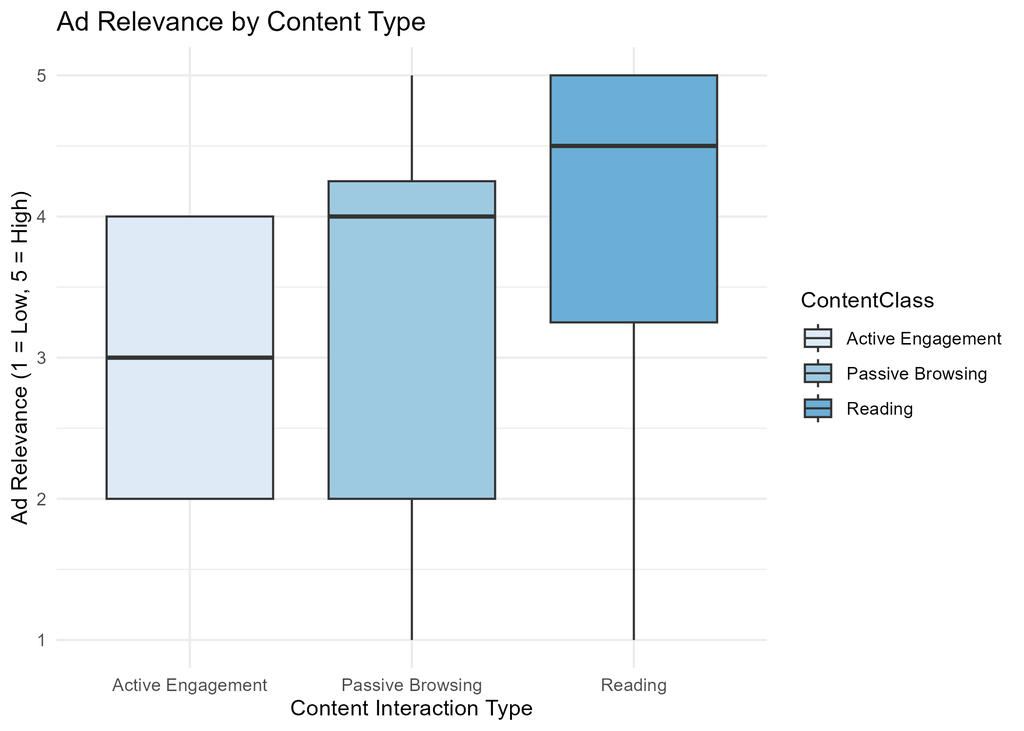

*Reading Relavancy*

Reading as a source of entertainment generates a lot of relevance as it covers a large amount of content that can be categorised broadly compared to video type media platforms.